# Intelligent Agents

Imran Ali

April 4, 2018

## What is Intelligent Agent?

An **autonomous entity** which observes through **sensors** and acts upon an environment using **actuators** and directs its activity towards achieving goals. A reflex machine such as a thermostat, is considered an example of an intelligent agent.

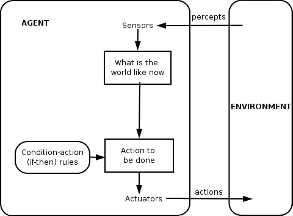

Simple reflex agent

More example of intelligent agents:

1. Trading agents in finance: The agent can sense(by checking fluctuations in rates or reading news) stock market, prize bonds or commoditiy market, and make buying or selling decisions.
2. Daignostic agent in medicine: observes the patient through various measurements e.g. blood pressure, heart rate, body temperature, and communicates the diagnosis to the doctor.
3. Crawling Agent: Retrieve the web pages from the world wide web, stores and sort the pages. When the user presents a query the agent returns the list of relevant pages.

The agent continously takes decisions in a cycle, called **perception action cycle**.